# **CONTENTS**

## 1. Project Introduction and Problem Statement

## 2. Importing Libraries and Dataset

## 3. Exploratory Data Analysis

### 3.1. Checking missing rows

### 3.2. Preprocessing Text

### 3.3. Anaysis and Visualization

## 4. Modelling (ML Approaches)

### 4.1. Spliting Data

### 4.2. ML pipelines & Evaluation

#### 4.2.1. Count Vectorizer + Logistic Regression

#### 4.2.2. Count Vectorizer + SVM

#### 4.2.3. Count Vectorizer + Naive Bayes

#### 4.2.4. Count Vectorizer + Artificial Neural Network

#### 4.2.5. TF-IDF + Logistic Regression

#### 4.2.6. TF-IDF + SVM

#### 4.2.7. TF-IDF + Naive Bayes

#### 4.2.8. TF-IDF + Artificial Neural Network

#### 4.2.9. Word Indexing + Convolutional Neural Network

#### 4.2.10. Word Indexing + Recurrent Neural Network

## 5. Summary of Trained ML Models

## 6. Conclusion

# 1. Project Introduction and Problem Statement

IMDB dataset having 50K movie reviews for natural language processing or Text analytics. This is a dataset for binary sentiment classification containing substantially more data than previous benchmark datasets. We provide a set of 25,000 highly polar movie reviews for training and 25,000 for testing. For more dataset information, please go through the following link, http://ai.stanford.edu/~amaas/data/sentiment/

**Problem Statement: The objective is to build robust machine learning model using Classification algorithms or Deep Learning algorithm with an aim to detect different types of emotion contained in a collection of English sentences or a large paragraph and accurately predict the overall emotion of the paragraph**

# 2. Importing Libraries and Dataset

```python
import plotly.express as px
import seaborn as sns
import wordcloud
from wordcloud import WordCloud
import matplotlib.pyplot as plt
import pandas as pd
import html
from nltk.tokenize import TreebankWordTokenizer
import re
import nltk
nltk.download('stopwords')
nltk.download('punkt')
nltk.download('wordnet')
import tensorflow as tf
from nltk.corpus import stopwords
from nltk.tokenize import word_tokenize
from nltk.stem import WordNetLemmatizer
from nltk.tokenize import word_tokenize
from keras.preprocessing.text import Tokenizer
from wordcloud import WordCloud
from sklearn.feature_extraction.text import CountVectorizer
from sklearn.feature_extraction.text import TfidfVectorizer
from sklearn.model_selection import train_test_split
from sklearn.linear_model import LogisticRegression
from sklearn.model_selection import RepeatedStratifiedKFold
from sklearn.model_selection import GridSearchCV
from sklearn.model_selection import ShuffleSplit
from sklearn.svm import LinearSVC
from sklearn.naive_bayes import BernoulliNB
from sklearn import metrics
from sklearn.metrics import accuracy_score
from sklearn.metrics import classification_report, confusion_matrix
%matplotlib inline
%config InlineBackend.figure_format = 'retina'
import numpy as np
from keras.wrappers.scikit_learn import KerasClassifier
from sklearn.model_selection import GridSearchCV
from keras.models import Sequential
from keras.layers import Dense
from keras.layers import Flatten
from keras.layers.convolutional import Conv1D
from keras.layers.convolutional import MaxPooling1D
from keras.layers.embeddings import Embedding
from keras.preprocessing import sequence
from keras.layers import Bidirectional
from keras.layers import LSTM

from IPython.display import Image
```

```python
data_path = tf.keras.utils.get_file("IMDB_Dataset.csv",
"https://studymachinelearning.com/wp-content/uploads/2020/03/IMDB-Dataset.csv",
)
df = pd.read_csv(data_path)
df.columns = ['text', 'sentiment'] ## naming the columns
df['sentiment'] = df['sentiment'].replace('negative', 0)
df['sentiment'] = df['sentiment'].replace('positive', 1)
df.head()

main_data = df
print(main_data.shape)
del df
```

```
(50000, 2)
```

Initially we have categories as positive and negative which has changed to 0 for negative and 1 for positive reviews

# 3. Exploratory Data Analysis

## 3.1. Checking missing rows

```python
main_data[main_data['text'].isnull()].count()
```

```
text         0
sentiment    0
dtype: int64
```

we don't have any missing values in the dataset

## 3.2. Preprocessing Text

```python
def stopwords_stemming(text):
    global stop
    custom_stopwords = ['br', 'like']
    stop = set(stopwords.words('english'))
    stop.update(custom_stopwords)
    text_tokens = word_tokenize(text)
    ## removing stopwords
    tokens_without_sw = [word for word in text_tokens if not word in stop]
    ## stemming
    lemmatizer=WordNetLemmatizer()
    tokens_with_stemming = []
    for word in tokens_without_sw:
        word = lemmatizer.lemmatize(word)
        tokens_with_stemming.append(word)
    filtered_sentence = (" ").join(tokens_with_stemming)
    return filtered_sentence


def cleaning_text(text):
    mentions = r'@[A-Za-z0-9]+'
    url_https = 'https?://[A-Za-z0-9./]+'
    url_www = r'www.[^ ]+'
    negations = {"isn't":"is not", "aren't":"are not", "wasn't":"was not", "weren't":"were not",
                 "haven't":"have not","hasn't":"has not","hadn't":"had not","won't":"will not",
                 "wouldn't":"would not", "don't":"do not", "doesn't":"does not","didn't":"did not",
                 "can't":"can not","couldn't":"could not","shouldn't":"should not","mightn't":"might not",
                 "mustn't":"must not"
                }

    text = html.unescape(text)
    text = re.sub(mentions, '', text)
    text = re.sub(url_https, '', text)
    text = re.sub(url_www, '', text)
    text = text.lower()
    for a, b in negations.items():
        if a in text:
            text = text.replace(a,b)
    #Removing characters except letters
    text = re.sub("[^a-zA-Z]", " ", text)
    #Removing unnecessary white spaces and stop words using tokenizer
    text = stopwords_stemming(text)
    return text


main_data['text'] = main_data['text'].apply(lambda x: cleaning_text(x))
main_data.head()
```

|  | text | sentiment |
| --- | --- | --- |
| 0 | one reviewer mentioned watching oz episode hoo... | 1 |
| 1 | wonderful little production filming technique ... | 1 |
| 2 | thought wonderful way spend time hot summer we... | 1 |
| 3 | basically family little boy jake think zombie ... | 0 |
| 4 | petter mattei love time money visually stunnin... | 1 |

## 3.3. Analysis and Visualization

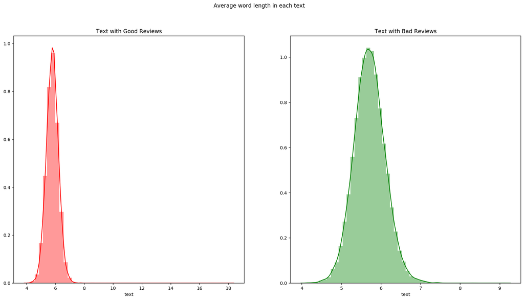

```python
fig,(ax1,ax2)=plt.subplots(1,2,figsize=(20,10))
word=main_data[main_data['sentiment']==1]['text'].str.split().apply(lambda x : [len(i) for i in x])
sns.distplot(word.map(lambda x: np.mean(x)),ax=ax1,color='red')
ax1.set_title('Text with Good Reviews')
word=main_data[main_data['sentiment']==0]['text'].str.split().apply(lambda x : [len(i) for i in x])
sns.distplot(word.map(lambda x: np.mean(x)),ax=ax2,color='green')
ax2.set_title('Text with Bad Reviews')
fig.suptitle('Average word length in each text')
del word
```

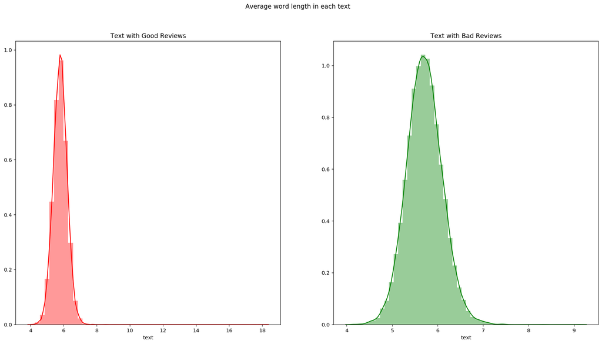

```python
fig
```

```
[Text(0, 0, 'Negative Tweets'), Text(0, 0, 'Positive Tweets')]
```

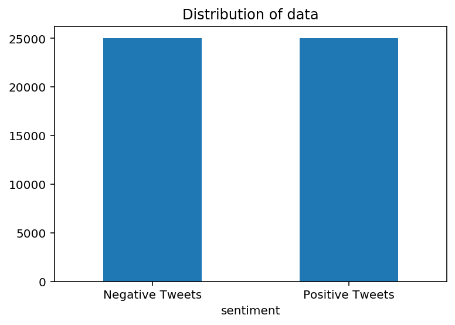

```python
ax = main_data.groupby('sentiment').count().plot(kind='bar', title='Distribution of data', legend=False)
ax.set_xticklabels(['Negative Tweets','Positive Tweets'], rotation=0)
```

```python
vect = CountVectorizer(stop_words='english', max_df = 0.50, min_df = 0.01)
vect.fit(main_data['text']) #Tokenise and build models
#Encoding document
neg_matrix = vect.transform(main_data[main_data.sentiment==0].text)
pos_matrix = vect.transform(main_data[main_data.sentiment==1].text)
neg_tf = np.sum(neg_matrix, axis=0)
pos_tf = np.sum(pos_matrix, axis=0)

#Remove single-dimensional entries from the shape of an array
neg = np.squeeze(np.asarray(neg_tf))
pos = np.squeeze(np.asarray(pos_tf))

term_freq_df = pd.DataFrame([neg, pos], columns = vect.get_feature_names()).transpose()
term_freq_df.columns = ['negative', 'positive']
term_freq_df['total'] = term_freq_df['negative'] + term_freq_df['positive']
term_freq_df.reset_index(inplace=True)
term_freq_df = term_freq_df.rename(columns = {'index':'words'})
term_freq_df.head()
```

|  | words | negative | positive | total |
| --- | --- | --- | --- | --- |
| 0 | ability | 550 | 601 | 1151 |
| 1 | able | 1155 | 1469 | 2624 |
| 2 | absolute | 377 | 300 | 677 |
| 3 | absolutely | 1702 | 1292 | 2994 |
| 4 | absurd | 393 | 162 | 555 |

[interactive chart not shown]

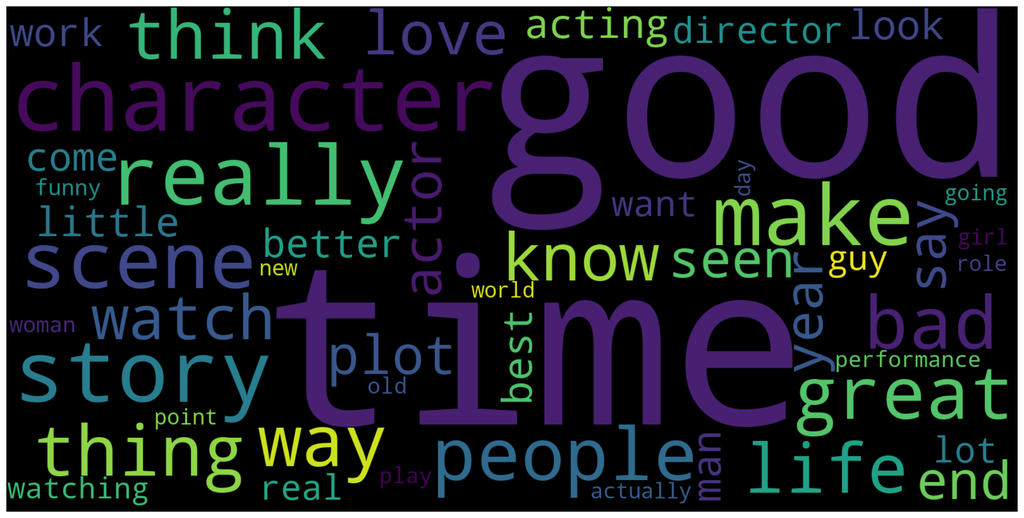

```python
complete_df = term_freq_df.nlargest(50,'total')  ## selecting top 50 words occuring in negative tweets
fig = px.bar(complete_df, x='words', y='total')
fig.show()

wordcloud = WordCloud(stopwords=stop,
                      random_state=42, width = 1600 , height = 800).generate_from_frequencies(frequencies=complete_df.set_index('words').to_dict()['total'])

fig = plt.figure(figsize=(20,20))
plt.imshow(wordcloud, interpolation='bilinear')
plt.axis('off')
plt.show()

del complete_df
```

[interactive chart not shown]

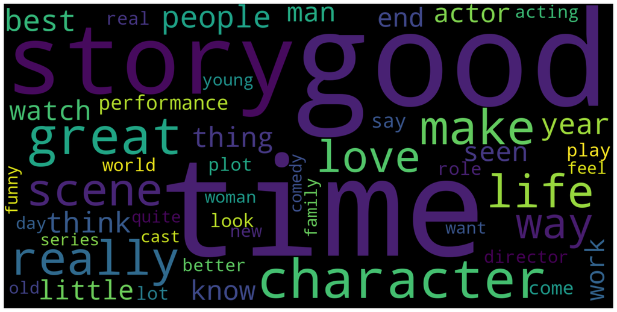

```python
pos_df = term_freq_df.nlargest(50,'positive')  ## selecting top 50 words occuring in negative tweets
fig = px.bar(pos_df, x='words', y='positive')
fig.show()

wordcloud = WordCloud(stopwords=stop,
                      random_state=42, width = 1600 , height = 800).generate_from_frequencies(frequencies=pos_df.set_index('words').to_dict()['positive'])

fig = plt.figure(figsize=(20,20))
plt.imshow(wordcloud, interpolation='bilinear')
plt.axis('off')
plt.show()

del pos_df
```

[interactive chart not shown]

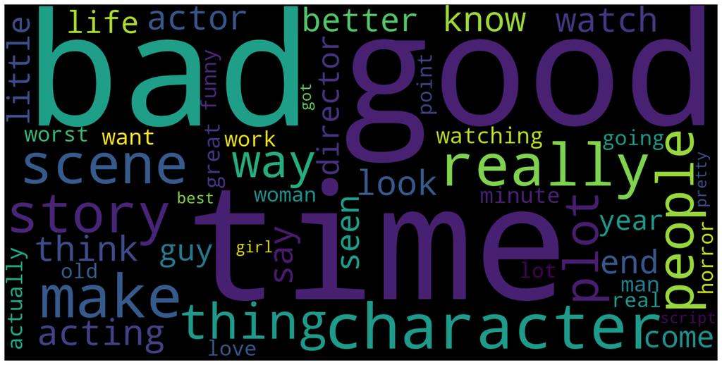

```python
neg_df = term_freq_df.nlargest(50,'negative')  ## selecting top 50 words occuring in negative tweets
fig = px.bar(neg_df, x='words', y='negative')
fig.show()

wordcloud = WordCloud(stopwords=stop,
                      random_state=42, width = 1600 , height = 800).generate_from_frequencies(frequencies=neg_df.set_index('words').to_dict()['negative'])

fig = plt.figure(figsize=(20,20))
plt.imshow(wordcloud, interpolation='bilinear')
plt.axis('off')
plt.show()

del neg_df
del term_freq_df
```

# 4. Modelling (ML Approaches)

## 4.1. Spliting Data

```python
X = main_data['text']
y = main_data['sentiment']
X_train, X_test, y_train, y_test = train_test_split(X, y, test_size=0.20, random_state=45)
```

## 4.2. ML pipelines & Evaluation

### 4.2.1. Count Vectorizer + Logistic Regression

```python
## creating vectorizer
vect = CountVectorizer(stop_words='english', ngram_range=(1, 1), max_features = 10000, binary=False)
vect.fit(X)
print(f'Vectoriser fitted.')
print('No. of feature_words: ', len(vect.get_feature_names()))

## transforming the data into Document Term Matrix
local_X_train = vect.transform(X_train)
local_X_test = vect.transform(X_test)
print(f'Data Transformed.')
```

```
Vectoriser fitted.
No. of feature_words:  10000
Data Transformed.
```

```python
def logistic_regression():

    ### using best parameters training the model and doing predictions
    Final_LRmodel = LogisticRegression(C = 2.0, max_iter = 1000)
    Final_LRmodel.fit(local_X_train.toarray(), y_train.values)
    predictions = Final_LRmodel.predict(local_X_test.toarray())
    print(classification_report(y_test.values, predictions))
    LR_accuracy = accuracy_score(y_test.values, predictions)
    print(f"\nAccuracy : {LR_accuracy}")

    return Final_LRmodel

CV_LR_model = logistic_regression()
############################################## FOR CV ###########################################
#     ## Training Logistic Regression model with hyperparameter tuning and GridsearchCV
#     LRmodel = LogisticRegression(solver='saga', penalty = 'l1', random_state=0, max_iter = 5000, multi_class = 'ovr')
#     # penalty = ['l1', 'l2', 'elasticnet']  ##  can also use ['l2', 'elasticnet'] but, will make grid bigger which takes more time.
#     c_values = [2.5, 2.0]
#     grid = dict(C=c_values)
#     cv = ShuffleSplit(test_size=0.20, n_splits=1, random_state=42)
#     grid_search = GridSearchCV(estimator=LRmodel, param_grid=grid, n_jobs=-1, cv=cv, scoring='accuracy',error_score=0, verbose=3)
#     grid_result = grid_search.fit(local_X_train.toarray(), y_train.values)
#     print("Best: %f using %s" % (grid_result.best_score_, grid_result.best_params_))
#     logistic_best_parameter = grid_result.best_params_

#     ### using best parameters training the model and doing predictions
#     Final_LRmodel = LogisticRegression(solver='saga', penalty = 'l1', random_state=0, max_iter = 5000, multi_class = 'ovr', C = logistic_best_parameter['C'])
#     Final_LRmodel.fit(local_X_train.toarray(), y_train.values)
#     predictions = Final_LRmodel.predict(local_X_test.toarray())
#     print(classification_report(y_test.values, predictions))
#     LR_accuracy = accuracy_score(y_test.values, predictions)
#######################################################################################################
```

```
              precision    recall  f1-score   support

           0       0.87      0.86      0.86      5035
           1       0.86      0.87      0.86      4965

    accuracy                           0.86     10000
   macro avg       0.86      0.86      0.86     10000
weighted avg       0.86      0.86      0.86     10000


Accuracy : 0.8624
```

### 4.2.2. Count Vectorizer + SVM

```python
def SVM():

    ### using best parameters training the model and doing predictions
    Final_SVMmodel = LinearSVC(C = 0.5, max_iter = 2000)
    Final_SVMmodel.fit(local_X_train.toarray(), y_train.values)
    predictions = Final_SVMmodel.predict(local_X_test.toarray())
    print(classification_report(y_test.values, predictions))
    SVM_accuracy = accuracy_score(y_test.values, predictions)
    print(f"\nAccuracy : {SVM_accuracy}")

    return Final_SVMmodel

CV_SVM_model = SVM()
```

```
              precision    recall  f1-score   support

           0       0.85      0.85      0.85      5035
           1       0.85      0.85      0.85      4965

    accuracy                           0.85     10000
   macro avg       0.85      0.85      0.85     10000
weighted avg       0.85      0.85      0.85     10000


Accuracy : 0.8503
```

### 4.2.3. Count Vectorizer + Bernoulli Naive Bayes

```python
def BNB():

    ### using best parameters training the model and doing predictions
    Final_BNBmodel = BernoulliNB(alpha = 1.0)
    Final_BNBmodel.fit(local_X_train.toarray(), y_train.values)
    predictions = Final_BNBmodel.predict(local_X_test.toarray())
    print(classification_report(y_test.values, predictions))
    BNB_accuracy = accuracy_score(y_test.values, predictions)
    print(f"\nAccuracy : {BNB_accuracy}")

    return Final_BNBmodel

CV_BNB_model = BNB()
```

```
              precision    recall  f1-score   support

           0       0.84      0.86      0.85      5035
           1       0.86      0.83      0.84      4965

    accuracy                           0.85     10000
   macro avg       0.85      0.85      0.85     10000
weighted avg       0.85      0.85      0.85     10000


Accuracy : 0.8472
```

### 4.2.4. Count Vectorizer + Artificial Neural Network

```python
def ann():
    def build_classifier(optimizer):
        classifier = Sequential()
        classifier.add(Dense(units = 16, kernel_initializer = 'uniform', activation = 'relu', input_dim = local_X_train.shape[1]))
        classifier.add(Dense(units = 16, kernel_initializer = 'uniform', activation = 'relu'))
        classifier.add(Dense(units = 1, kernel_initializer = 'uniform', activation = 'sigmoid'))
        classifier.compile(optimizer = optimizer, loss = 'binary_crossentropy', metrics = ['accuracy'])
        return classifier

    classifier = KerasClassifier(build_fn = build_classifier)
    parameters = {'batch_size': [100, 300, 500, 700],
                  'epochs': [5, 10, 15, 20],
                  'optimizer': ['adam']}
    grid_search = GridSearchCV(estimator = classifier,
                               param_grid = parameters,
                               scoring = 'accuracy',
                               cv = ShuffleSplit(test_size=0.20, n_splits=1, random_state=42)
                               )

    grid_search = grid_search.fit(local_X_train.toarray(), y_train.values)
    best_parameters = grid_search.best_params_
    best_accuracy = grid_search.best_score_
    cv_results = grid_search.cv_results_
    cv_results = pd.DataFrame(cv_results)

    ## visualizing cv cv_results
    ann_fig = px.scatter(cv_results, x="param_batch_size", y="mean_test_score", color="param_epochs",
                 hover_data=['params'], title="Cross Validation Results for ANN",
            width=600, height=600,
            labels={ # replaces default labels by column name
                "param_batch_size": "Batch Size",  "mean_test_score": "Accuracy", "param_epochs": "Epochs"
            }, template="simple_white")
    ann_fig.show()

    ## training ann with the best parameters
    classifier = build_classifier(best_parameters['optimizer'])
    history = classifier.fit(local_X_train.toarray(), y_train.values, batch_size = best_parameters['batch_size'], epochs = best_parameters['epochs'])

    # Predicting the Test set results
    predictions = classifier.predict(local_X_test.toarray())
    predictions = (predictions > 0.5) ### if >0.5 then 1 otherwise 0
    print(classification_report(y_test.values, predictions))
    accuracy = accuracy_score(y_test.values, predictions)
    print (f"\nAccuracy is {accuracy}")

    return classifier
```

```python
CV_ANN_model = ann()
```

[interactive chart not shown]

```
              precision    recall  f1-score   support

           0       0.90      0.88      0.89      5035
           1       0.88      0.90      0.89      4965

    accuracy                           0.89     10000
   macro avg       0.89      0.89      0.89     10000
weighted avg       0.89      0.89      0.89     10000


Accuracy is 0.889
```

### 4.2.5. TF-IDF + Logistic Regression

```python
## creating vectorizer
tfvect = TfidfVectorizer(stop_words='english', ngram_range=(1, 1), max_features = 10000, binary=False)
tfvect.fit(X)
print(f'TF-IDF Vectoriser fitted.')
print('No. of feature_words: ', len(tfvect.get_feature_names()))

## transforming the data into Document Term Matrix

## new Local_X_train and test
local_X_train = tfvect.transform(X_train)
local_X_test = tfvect.transform(X_test)
print(f'Data Transformed.')
```

```
TF-IDF Vectoriser fitted.
No. of feature_words:  10000
Data Transformed.
```

```python
def logistic_regression():

    ### using best parameters training the model and doing predictions
    Final_LRmodel = LogisticRegression(C = 2.0, max_iter = 1000)
    Final_LRmodel.fit(local_X_train.toarray(), y_train.values)
    predictions = Final_LRmodel.predict(local_X_test.toarray())
    print(classification_report(y_test.values, predictions))
    LR_accuracy = accuracy_score(y_test.values, predictions)
    print(f"\nAccuracy : {LR_accuracy}")

    return Final_LRmodel

TFIDF_LR_model = logistic_regression()
```

```
              precision    recall  f1-score   support

           0       0.90      0.88      0.89      5035
           1       0.88      0.90      0.89      4965

    accuracy                           0.89     10000
   macro avg       0.89      0.89      0.89     10000
weighted avg       0.89      0.89      0.89     10000


Accuracy : 0.891
```

### 4.2.6. TF-IDF + SVM

```python
def SVM():

    ### using best parameters training the model and doing predictions
    Final_SVMmodel = LinearSVC(C = 0.5, max_iter = 2000)
    Final_SVMmodel.fit(local_X_train.toarray(), y_train.values)
    predictions = Final_SVMmodel.predict(local_X_test.toarray())
    print(classification_report(y_test.values, predictions))
    SVM_accuracy = accuracy_score(y_test.values, predictions)
    print(f"\nAccuracy : {SVM_accuracy}")

    return Final_SVMmodel

TFIDF_SVM_model = SVM()
```

```
              precision    recall  f1-score   support

           0       0.89      0.88      0.89      5035
           1       0.88      0.89      0.89      4965

    accuracy                           0.89     10000
   macro avg       0.89      0.89      0.89     10000
weighted avg       0.89      0.89      0.89     10000


Accuracy : 0.8856
```

### 4.2.7. TF-IDF + Naive Bayes

```python
def BNB():

    ### using best parameters training the model and doing predictions
    Final_BNBmodel = BernoulliNB(alpha = 1.0)
    Final_BNBmodel.fit(local_X_train.toarray(), y_train.values)
    predictions = Final_BNBmodel.predict(local_X_test.toarray())
    print(classification_report(y_test.values, predictions))
    BNB_accuracy = accuracy_score(y_test.values, predictions)
    print(f"\nAccuracy : {BNB_accuracy}")

    return Final_BNBmodel

TFIDF_BNB_model = BNB()
```

```
              precision    recall  f1-score   support

           0       0.84      0.86      0.85      5035
           1       0.86      0.83      0.84      4965

    accuracy                           0.85     10000
   macro avg       0.85      0.85      0.85     10000
weighted avg       0.85      0.85      0.85     10000


Accuracy : 0.8472
```

### 4.2.8. TF-IDF + Artificial Neural Network

```python
def ann():
    def build_classifier(optimizer):
        classifier = Sequential()
        classifier.add(Dense(units = 16, kernel_initializer = 'uniform', activation = 'relu', input_dim = local_X_train.shape[1]))
        classifier.add(Dense(units = 16, kernel_initializer = 'uniform', activation = 'relu'))
        classifier.add(Dense(units = 1, kernel_initializer = 'uniform', activation = 'sigmoid'))
        classifier.compile(optimizer = optimizer, loss = 'binary_crossentropy', metrics = ['accuracy'])
        return classifier

    classifier = KerasClassifier(build_fn = build_classifier)
    parameters = {'batch_size': [100, 300, 500, 700],
                  'epochs': [5, 10, 15, 20],
                  'optimizer': ['adam']}
    grid_search = GridSearchCV(estimator = classifier,
                               param_grid = parameters,
                               scoring = 'accuracy',
                               cv = ShuffleSplit(test_size=0.20, n_splits=1, random_state=42)
                               )

    grid_search = grid_search.fit(local_X_train.toarray(), y_train.values)
    best_parameters = grid_search.best_params_
    best_accuracy = grid_search.best_score_
    cv_results = grid_search.cv_results_
    cv_results = pd.DataFrame(cv_results)

    ## visualizing cv cv_results
    global ann2_fig
    ann2_fig = px.scatter(cv_results, x="param_batch_size", y="mean_test_score", color="param_epochs",
                 hover_data=['params'], title="Cross Validation Results for ANN",
            width=600, height=600,
            labels={ # replaces default labels by column name
                "param_batch_size": "Batch Size",  "mean_test_score": "Accuracy", "param_epochs": "Epochs"
            }, template="simple_white")
    ann2_fig.show()

    ## training ann with the best parameters
    classifier = build_classifier(best_parameters['optimizer'])
    history = classifier.fit(local_X_train.toarray(), y_train.values, batch_size = best_parameters['batch_size'], epochs = best_parameters['epochs'])

    # Predicting the Test set results
    predictions = classifier.predict(local_X_test.toarray())
    predictions = (predictions > 0.5) ### if >0.5 then 1 otherwise 0
    print(classification_report(y_test.values, predictions))
    accuracy = accuracy_score(y_test.values, predictions)
    print (f"\nAccuracy is {accuracy}")

    return classifier
```

```python
TFIDF_ANN_model = ann()
```

[interactive chart not shown]

```
              precision    recall  f1-score   support

           0       0.90      0.89      0.89      5035
           1       0.89      0.89      0.89      4965

    accuracy                           0.89     10000
   macro avg       0.89      0.89      0.89     10000
weighted avg       0.89      0.89      0.89     10000


Accuracy is 0.892
```

### 4.2.9. Word Indexing + Convolutional Neural Network

```python
def cnn():

    # vectorize the text samples into a 2D integer tensor
    max_features = 10000 ##vocab size
    tokenizer = Tokenizer(nb_words=max_features)
    tokenizer.fit_on_texts(X)
    sequences_train = tokenizer.texts_to_sequences(X_train)
    sequences_test = tokenizer.texts_to_sequences(X_test)
    # Padding the data samples to a maximum review length in words
    max_words = 450
    local_X_train = sequence.pad_sequences(sequences_train, maxlen=max_words)
    local_X_test = sequence.pad_sequences(sequences_test, maxlen=max_words)

    def build_classifier(optimizer):
        # Building the CNN Model
        classifier = Sequential()      # initilaizing the Sequential nature for CNN model
        # Adding the embedding layer which will take in maximum of 450 words as input and provide a 32 dimensional output of those words which belong in the top_words dictionary
        classifier.add(Embedding(max_features, 32, input_length=max_words))
        classifier.add(Conv1D(32, 3, padding='same', activation='relu'))
        classifier.add(MaxPooling1D())
        classifier.add(Flatten())
        classifier.add(Dense(250, kernel_initializer = 'uniform', activation='relu'))
        classifier.add(Dense(1, kernel_initializer = 'uniform', activation='sigmoid'))
        classifier.compile(optimizer = optimizer, loss='binary_crossentropy', metrics=['accuracy'])
        return classifier

    classifier = KerasClassifier(build_fn = build_classifier)
    parameters = {'batch_size': [100, 300, 500, 700],
                  'epochs': [5, 10, 15, 20],
                  'optimizer': ['adam']}
    grid_search = GridSearchCV(estimator = classifier,
                               param_grid = parameters,
                               scoring = 'accuracy',
                               cv = ShuffleSplit(test_size=0.20, n_splits=1, random_state=42)
                               )

    grid_search = grid_search.fit(local_X_train, y_train.values)
    best_parameters = grid_search.best_params_
    best_accuracy = grid_search.best_score_
    cv_results = grid_search.cv_results_
    cv_results = pd.DataFrame(cv_results)

    ## visualizing cv cv_results
    cnn_fig = px.scatter(cv_results, x="param_batch_size", y="mean_test_score", color="param_epochs",
                 hover_data=['params'], title="Cross Validation Results for CNN",
            width=600, height=600,
            labels={ # replaces default labels by column name
                "param_batch_size": "Batch Size",  "mean_test_score": "Accuracy", "param_epochs": "Epochs"
            }, template="simple_white")
    cnn_fig.show()

    ## training cnn with the best parameters
    classifier = build_classifier(best_parameters['optimizer'])
    history = classifier.fit(local_X_train, y_train.values, batch_size = best_parameters['batch_size'], epochs = best_parameters['epochs'])

    # Predicting the Test set results
    predictions = classifier.predict(local_X_test)
    predictions = (predictions > 0.5) ### if >0.5 then 1 otherwise 0
    print(classification_report(y_test.values, predictions))
    accuracy = accuracy_score(y_test.values, predictions)
    print (f"\nAccuracy is {accuracy}")

    return classifier, tokenizer
```

```python
CNN_model, CNN_tokenizer = cnn()
```

[interactive chart not shown]

```
              precision    recall  f1-score   support

           0       0.89      0.87      0.88      5035
           1       0.87      0.89      0.88      4965

    accuracy                           0.88     10000
   macro avg       0.88      0.88      0.88     10000
weighted avg       0.88      0.88      0.88     10000


Accuracy is 0.8833
```

### 4.2.10. Word Indexing + Recurrent Neural Network

```python
def rnn():
    # vectorize the text samples into a 2D integer tensor
    max_features = 10000 ##vocab size
    tokenizer = Tokenizer(nb_words=max_features)
    tokenizer.fit_on_texts(X)
    sequences_train = tokenizer.texts_to_sequences(X_train)
    sequences_test = tokenizer.texts_to_sequences(X_test)
    # Padding the data samples to a maximum review length in words
    max_words = 450
    local_X_train = sequence.pad_sequences(sequences_train, maxlen=max_words)
    local_X_test = sequence.pad_sequences(sequences_test, maxlen=max_words)

    def build_classifier(optimizer):
        # Building the CNN Model
        classifier = Sequential()      # initilaizing the Sequential nature for CNN model
        # Adding the embedding layer which will take in maximum of 450 words as input and provide a 32 dimensional output of those words which belong in the top_words dictionary
        classifier.add(Embedding(max_features, 32, input_length=max_words))
        classifier.add(Bidirectional(LSTM(32)))
        classifier.add(Dense(250, kernel_initializer = 'uniform', activation='relu'))
        classifier.add(Dense(1, kernel_initializer = 'uniform', activation='sigmoid'))
        classifier.compile(optimizer = optimizer, loss='binary_crossentropy', metrics=['accuracy'])
        return classifier

    classifier = KerasClassifier(build_fn = build_classifier)
    parameters = {'batch_size': [100, 300, 500, 700],
                  'epochs': [5, 10, 15, 20],
                  'optimizer': ['adam']}
    grid_search = GridSearchCV(estimator = classifier,
                               param_grid = parameters,
                               scoring = 'accuracy',
                               cv = ShuffleSplit(test_size=0.20, n_splits=1, random_state=42)
                               )

    grid_search = grid_search.fit(local_X_train, y_train.values)
    best_parameters = grid_search.best_params_
    best_accuracy = grid_search.best_score_
    cv_results = grid_search.cv_results_
    cv_results = pd.DataFrame(cv_results)

    ## visualizing cv cv_results
    rnn_fig = px.scatter(cv_results, x="param_batch_size", y="mean_test_score", color="param_epochs",
                 hover_data=['params'], title="Cross Validation Results for RNN",
            width=600, height=600,
            labels={ # replaces default labels by column name
                "param_batch_size": "Batch Size",  "mean_test_score": "Accuracy", "param_epochs": "Epochs"
            }, template="simple_white")
    rnn_fig.show()

    ## training cnn with the best parameters
    classifier = build_classifier(best_parameters['optimizer'])
    history = classifier.fit(local_X_train, y_train.values, batch_size = best_parameters['batch_size'], epochs = best_parameters['epochs'])

    # Predicting the Test set results
    predictions = classifier.predict(local_X_test)
    predictions = (predictions > 0.5) ### if >0.5 then 1 otherwise 0
    print(classification_report(y_test.values, predictions))
    accuracy = accuracy_score(y_test.values, predictions)
    print (f"\nAccuracy is {accuracy}")

    return classifier, tokenizer
```

```python
RNN_model, RNN_tokenizer = rnn()
```

[interactive chart not shown]

```
              precision    recall  f1-score   support

           0       0.89      0.88      0.88      5035
           1       0.88      0.88      0.88      4965

    accuracy                           0.88     10000
   macro avg       0.88      0.88      0.88     10000
weighted avg       0.88      0.88      0.88     10000


Accuracy is 0.8831
```

# 5. Summary of Trained ML Models

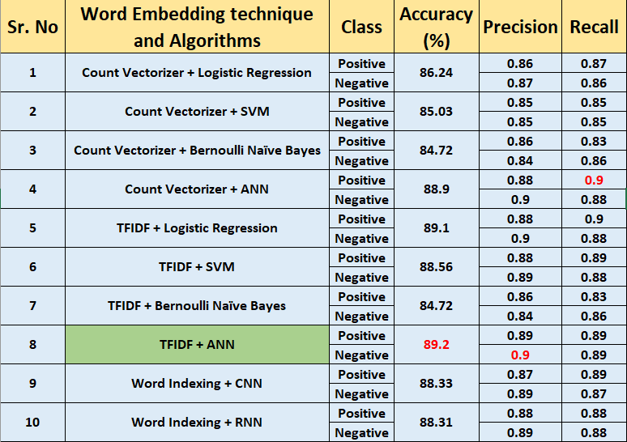

```python
Image("comparison table.PNG")
```

In the above table we can observe that Artificial Neural Net TF-IDF word embedding technique gives the best results and achieved **89.20 %** accuracy. This model will perform equally in predicting both positive text and negative text as we have equal recall for both the classes.

> lets see the grid search result of best performing model

```python
ann2_fig.show()
```

[interactive chart not shown]

we can clearly see our best performing parameters batch size = 500 and epochs = 5.

**Future Work:** There is a good chance that if we increase our gird size and new parameters like optimizer in the current NN then accuracy will increase further. All the parameters and size of the grid is finalized considering computation power of google colab and kaggle. we can make network more dense or add more hidden layers or add neurons to those layers to see some significant improvement in the result.

Testing out best model

```python
## below review is the actual review of "Scam 1992" TV Series with good rating

Text = ["Okay, so the bottom line is 'harshad mehta' was involved in most of the wrong \
        doing but was he the only guy responsible ? No, Never. In a scam like huge as 1992 \
        shown in this series, it was never one person befooling the entire nation. \
        This show has 2 names written all over it, pratik gandhi (harshad mehta) and \
        the creator himself Hansal mehta. What a crazy show he has pulled off, \
        no big actors with huge following but bunch of actors who have shown their \
        par excellence in this 9 episode long series. this is the best work of hansal \
        mehta that he has pulled of in his career. From the scene 1 to the last pratik \
        gandhi has stole the show. what a great addition to the film industry. \
        The strongest point in this very complicated series filled with so many jargons is the \
        fact is it's screenplay. to the point, no nonsense, no strong language without any use, \
        no vulgarity and just a focus on story-line. a Strong screenplay and good direction is \
        always the key to the film series and SCAM 1992 is here to proof. don't think just watch it, \
        you love it and want to watch it in just one go. too good to be made for an Indian audience \
        which focuses only on one thing a good meme templates, which this series is definitely not."]

### Best performing model is the combination of TF-IDF word embedding technique and Artificial Neural Network
### with 2 hidden layers with 16 neurons each.
def best_model_result(text):
    temp = cleaning_text(text[0])
    temp = tfvect.transform(text)
    prediction = TFIDF_ANN_model.predict(temp.toarray())
    prediction = (prediction > 0.5)
    if prediction == True:
        print ("This text has Positive sentiment")
    else:
        print ("This text has Negative sentiment")

best_model_result(Text)
```

```
This text has Positive sentiment
```

# 6. Conclusion

we have started this project by selecting the balanced labelled dataset, checking missing values, trying out different word embedding techniques with a combination of machine learning algorithms. we have also seen that selecting different word embedding technique affects the end result.

**Best Model performance : 89.20 % (Artificial Neural Network)**